# Optimal Treatment Analysis

## Outcome Variable

**Outcome Variable:** haz

## Predictor Variables

**Intervention Variable:** hdlvry

**Adjustment Set:**

- arm
- sex
- W_mage
- meducyrs
- feducyrs
- hhwealth_quart
- single
- W_nrooms
- brthmon
- W_parity
- impsan
- delta_W_mage
- delta_meducyrs
- delta_feducyrs
- delta_hhwealth_quart
- delta_single
- delta_W_nrooms
- delta_brthmon
- delta_W_parity
- delta_impsan

## Stratifying Variables

The analysis was stratified on these variable(s):

- agecat
- studyid
- country

## Data Summary

| agecat | studyid | country | hdlvry | n_cell | n |
| --- | --- | --- | --- | --- | --- |
| Birth | ki1000108-CMC-V-BCS-2002 | INDIA | 0 | 92 | 92 |
| Birth | ki1000108-CMC-V-BCS-2002 | INDIA | 1 | 0 | 92 |
| Birth | ki1000108-IRC | INDIA | 0 | 381 | 388 |
| Birth | ki1000108-IRC | INDIA | 1 | 7 | 388 |
| Birth | ki1000109-EE | PAKISTAN | 0 | 161 | 238 |
| Birth | ki1000109-EE | PAKISTAN | 1 | 77 | 238 |
| Birth | ki1000304b-SAS-CompFeed | INDIA | 0 | 124 | 1085 |
| Birth | ki1000304b-SAS-CompFeed | INDIA | 1 | 961 | 1085 |
| Birth | ki1017093b-PROVIDE | BANGLADESH | 0 | 391 | 539 |
| Birth | ki1017093b-PROVIDE | BANGLADESH | 1 | 148 | 539 |
| Birth | ki1017093c-NIH-Crypto | BANGLADESH | 0 | 567 | 732 |
| Birth | ki1017093c-NIH-Crypto | BANGLADESH | 1 | 165 | 732 |
| Birth | ki1113344-GMS-Nepal | NEPAL | 0 | 157 | 646 |
| Birth | ki1113344-GMS-Nepal | NEPAL | 1 | 489 | 646 |
| Birth | ki1135781-COHORTS | INDIA | 0 | 2938 | 4694 |
| Birth | ki1135781-COHORTS | INDIA | 1 | 1756 | 4694 |
| Birth | kiGH5241-JiVitA-3 | BANGLADESH | 0 | 30 | 334 |
| Birth | kiGH5241-JiVitA-3 | BANGLADESH | 1 | 304 | 334 |
| Birth | kiGH5241-JiVitA-4 | BANGLADESH | 0 | 554 | 2808 |
| Birth | kiGH5241-JiVitA-4 | BANGLADESH | 1 | 2254 | 2808 |
| 6 months | ki1000108-CMC-V-BCS-2002 | INDIA | 0 | 358 | 366 |
| 6 months | ki1000108-CMC-V-BCS-2002 | INDIA | 1 | 8 | 366 |
| 6 months | ki1000108-IRC | INDIA | 0 | 399 | 407 |
| 6 months | ki1000108-IRC | INDIA | 1 | 8 | 407 |
| 6 months | ki1000109-EE | PAKISTAN | 0 | 250 | 371 |
| 6 months | ki1000109-EE | PAKISTAN | 1 | 121 | 371 |
| 6 months | ki1000304b-SAS-CompFeed | INDIA | 0 | 147 | 1091 |
| 6 months | ki1000304b-SAS-CompFeed | INDIA | 1 | 944 | 1091 |
| 6 months | ki1000304b-SAS-FoodSuppl | INDIA | 0 | 76 | 380 |
| 6 months | ki1000304b-SAS-FoodSuppl | INDIA | 1 | 304 | 380 |
| 6 months | ki1017093b-PROVIDE | BANGLADESH | 0 | 450 | 604 |
| 6 months | ki1017093b-PROVIDE | BANGLADESH | 1 | 154 | 604 |
| 6 months | ki1017093c-NIH-Crypto | BANGLADESH | 0 | 554 | 715 |
| 6 months | ki1017093c-NIH-Crypto | BANGLADESH | 1 | 161 | 715 |
| 6 months | ki1066203-TanzaniaChild2 | TANZANIA, UNITED REPUBLIC OF | 0 | 1889 | 1921 |
| 6 months | ki1066203-TanzaniaChild2 | TANZANIA, UNITED REPUBLIC OF | 1 | 32 | 1921 |
| 6 months | ki1113344-GMS-Nepal | NEPAL | 0 | 129 | 528 |
| 6 months | ki1113344-GMS-Nepal | NEPAL | 1 | 399 | 528 |
| 6 months | ki1135781-COHORTS | INDIA | 0 | 2900 | 4699 |
| 6 months | ki1135781-COHORTS | INDIA | 1 | 1799 | 4699 |
| 6 months | kiGH5241-JiVitA-3 | BANGLADESH | 0 | 39 | 332 |
| 6 months | kiGH5241-JiVitA-3 | BANGLADESH | 1 | 293 | 332 |
| 6 months | kiGH5241-JiVitA-4 | BANGLADESH | 0 | 1081 | 4038 |
| 6 months | kiGH5241-JiVitA-4 | BANGLADESH | 1 | 2957 | 4038 |
| 24 months | ki1000108-CMC-V-BCS-2002 | INDIA | 0 | 360 | 368 |
| 24 months | ki1000108-CMC-V-BCS-2002 | INDIA | 1 | 8 | 368 |
| 24 months | ki1000108-IRC | INDIA | 0 | 401 | 409 |
| 24 months | ki1000108-IRC | INDIA | 1 | 8 | 409 |
| 24 months | ki1000109-EE | PAKISTAN | 0 | 112 | 166 |
| 24 months | ki1000109-EE | PAKISTAN | 1 | 54 | 166 |
| 24 months | ki1017093b-PROVIDE | BANGLADESH | 0 | 433 | 578 |
| 24 months | ki1017093b-PROVIDE | BANGLADESH | 1 | 145 | 578 |
| 24 months | ki1017093c-NIH-Crypto | BANGLADESH | 0 | 391 | 514 |
| 24 months | ki1017093c-NIH-Crypto | BANGLADESH | 1 | 123 | 514 |
| 24 months | ki1066203-TanzaniaChild2 | TANZANIA, UNITED REPUBLIC OF | 0 | 6 | 6 |
| 24 months | ki1066203-TanzaniaChild2 | TANZANIA, UNITED REPUBLIC OF | 1 | 0 | 6 |
| 24 months | ki1113344-GMS-Nepal | NEPAL | 0 | 118 | 456 |
| 24 months | ki1113344-GMS-Nepal | NEPAL | 1 | 338 | 456 |
| 24 months | ki1135781-COHORTS | INDIA | 0 | 2233 | 3556 |
| 24 months | ki1135781-COHORTS | INDIA | 1 | 1323 | 3556 |
| 24 months | kiGH5241-JiVitA-3 | BANGLADESH | 0 | 35 | 291 |
| 24 months | kiGH5241-JiVitA-3 | BANGLADESH | 1 | 256 | 291 |
| 24 months | kiGH5241-JiVitA-4 | BANGLADESH | 0 | 1033 | 4005 |
| 24 months | kiGH5241-JiVitA-4 | BANGLADESH | 1 | 2972 | 4005 |

The following strata were considered:

- agecat: 24 months, studyid: ki1000108-CMC-V-BCS-2002, country: INDIA
- agecat: 24 months, studyid: ki1000108-IRC, country: INDIA
- agecat: 24 months, studyid: ki1000109-EE, country: PAKISTAN
- agecat: 24 months, studyid: ki1017093b-PROVIDE, country: BANGLADESH
- agecat: 24 months, studyid: ki1017093c-NIH-Crypto, country: BANGLADESH
- agecat: 24 months, studyid: ki1066203-TanzaniaChild2, country: TANZANIA, UNITED REPUBLIC OF
- agecat: 24 months, studyid: ki1113344-GMS-Nepal, country: NEPAL
- agecat: 24 months, studyid: ki1135781-COHORTS, country: INDIA
- agecat: 24 months, studyid: kiGH5241-JiVitA-3, country: BANGLADESH
- agecat: 24 months, studyid: kiGH5241-JiVitA-4, country: BANGLADESH
- agecat: 6 months, studyid: ki1000108-CMC-V-BCS-2002, country: INDIA
- agecat: 6 months, studyid: ki1000108-IRC, country: INDIA
- agecat: 6 months, studyid: ki1000109-EE, country: PAKISTAN
- agecat: 6 months, studyid: ki1000304b-SAS-CompFeed, country: INDIA
- agecat: 6 months, studyid: ki1000304b-SAS-FoodSuppl, country: INDIA
- agecat: 6 months, studyid: ki1017093b-PROVIDE, country: BANGLADESH
- agecat: 6 months, studyid: ki1017093c-NIH-Crypto, country: BANGLADESH
- agecat: 6 months, studyid: ki1066203-TanzaniaChild2, country: TANZANIA, UNITED REPUBLIC OF
- agecat: 6 months, studyid: ki1113344-GMS-Nepal, country: NEPAL
- agecat: 6 months, studyid: ki1135781-COHORTS, country: INDIA
- agecat: 6 months, studyid: kiGH5241-JiVitA-3, country: BANGLADESH
- agecat: 6 months, studyid: kiGH5241-JiVitA-4, country: BANGLADESH
- agecat: Birth, studyid: ki1000108-CMC-V-BCS-2002, country: INDIA
- agecat: Birth, studyid: ki1000108-IRC, country: INDIA
- agecat: Birth, studyid: ki1000109-EE, country: PAKISTAN
- agecat: Birth, studyid: ki1000304b-SAS-CompFeed, country: INDIA
- agecat: Birth, studyid: ki1017093b-PROVIDE, country: BANGLADESH
- agecat: Birth, studyid: ki1017093c-NIH-Crypto, country: BANGLADESH
- agecat: Birth, studyid: ki1113344-GMS-Nepal, country: NEPAL
- agecat: Birth, studyid: ki1135781-COHORTS, country: INDIA
- agecat: Birth, studyid: kiGH5241-JiVitA-3, country: BANGLADESH
- agecat: Birth, studyid: kiGH5241-JiVitA-4, country: BANGLADESH

### Dropped Strata

- agecat: Birth, studyid: ki1000108-CMC-V-BCS-2002, country: INDIA
- agecat: 24 months, studyid: ki1066203-TanzaniaChild2, country: TANZANIA, UNITED REPUBLIC OF

## Methods Detail

We’re interested in the causal parameters $E[Y_a]$ for all values of $a \in \mathcal{A}$. These parameters represent the mean outcome if, possibly contrary to fact, we intervened to set all units to have $A=a$. Under the randomization and positivity assumptions, these are identified by the statistical parameters $\psi_a=E_W[E_{Y|A,W}(Y|A=a,W)]$. In addition, we’re interested in the mean of $Y$, $E[Y]$ under no intervention (the observed mean). We will estimate these parameters by using SuperLearner to fit the relevant likelihood factors – $E_{Y|A,W}(Y|A=a,W)$ and $p(A=a|W)$, and then updating our likelihood fit using a joint TMLE.

For unadjusted analyses ($W=\{\}$), initial likelihoods were estimated using Lrnr_glm to estimate the simple $E(Y|A)$ and Lrnr_mean to estimate $p(A)$. For adjusted analyses, a small library containing Lrnr_glmnet, Lrnr_xgboost, and Lrnr_mean was used.

Having estimated these parameters, we will then use the delta method to estimate relative risks and attributable risks relative to a prespecified baseline level of $A$.

# Results Detail

## Results Plots

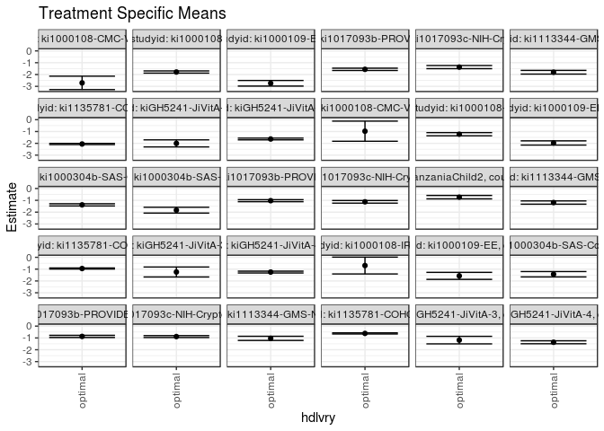

## Results Table

### Parameter: TSM

| agecat | studyid | country | intervention_level | baseline_level | estimate | ci_lower | ci_upper |
| --- | --- | --- | --- | --- | --- | --- | --- |
| Birth | ki1000108-IRC | INDIA | optimal | observed | -0.6956006 | -1.4071970 | 0.0159958 |
| Birth | ki1000109-EE | PAKISTAN | optimal | observed | -1.5704054 | -1.8663613 | -1.2744496 |
| Birth | ki1000304b-SAS-CompFeed | INDIA | optimal | observed | -1.4321840 | -1.6590986 | -1.2052693 |
| Birth | ki1017093b-PROVIDE | BANGLADESH | optimal | observed | -0.8711451 | -0.9618811 | -0.7804091 |
| Birth | ki1017093c-NIH-Crypto | BANGLADESH | optimal | observed | -0.8838879 | -0.9636711 | -0.8041048 |
| Birth | ki1113344-GMS-Nepal | NEPAL | optimal | observed | -1.0339979 | -1.2103814 | -0.8576145 |
| Birth | ki1135781-COHORTS | INDIA | optimal | observed | -0.6168481 | -0.6629459 | -0.5707503 |
| Birth | kiGH5241-JiVitA-3 | BANGLADESH | optimal | observed | -1.1835038 | -1.5029682 | -0.8640394 |
| Birth | kiGH5241-JiVitA-4 | BANGLADESH | optimal | observed | -1.3655324 | -1.4905236 | -1.2405413 |
| 6 months | ki1000108-CMC-V-BCS-2002 | INDIA | optimal | observed | -0.9727727 | -1.8239103 | -0.1216351 |
| 6 months | ki1000108-IRC | INDIA | optimal | observed | -1.2276507 | -1.3618601 | -1.0934412 |
| 6 months | ki1000109-EE | PAKISTAN | optimal | observed | -1.9683523 | -2.1469114 | -1.7897932 |
| 6 months | ki1000304b-SAS-CompFeed | INDIA | optimal | observed | -1.3831689 | -1.4747593 | -1.2915784 |
| 6 months | ki1000304b-SAS-FoodSuppl | INDIA | optimal | observed | -1.8321190 | -2.0779667 | -1.5862712 |
| 6 months | ki1017093b-PROVIDE | BANGLADESH | optimal | observed | -1.0311864 | -1.1171007 | -0.9452721 |
| 6 months | ki1017093c-NIH-Crypto | BANGLADESH | optimal | observed | -1.1272213 | -1.2396951 | -1.0147476 |
| 6 months | ki1066203-TanzaniaChild2 | TANZANIA, UNITED REPUBLIC OF | optimal | observed | -0.7309186 | -0.8750911 | -0.5867460 |
| 6 months | ki1113344-GMS-Nepal | NEPAL | optimal | observed | -1.1883979 | -1.3266468 | -1.0501490 |
| 6 months | ki1135781-COHORTS | INDIA | optimal | observed | -0.9492284 | -0.9939506 | -0.9045062 |
| 6 months | kiGH5241-JiVitA-3 | BANGLADESH | optimal | observed | -1.2424893 | -1.6643230 | -0.8206556 |
| 6 months | kiGH5241-JiVitA-4 | BANGLADESH | optimal | observed | -1.2490550 | -1.3254596 | -1.1726505 |
| 24 months | ki1000108-CMC-V-BCS-2002 | INDIA | optimal | observed | -2.7079313 | -3.2752248 | -2.1406378 |
| 24 months | ki1000108-IRC | INDIA | optimal | observed | -1.7872343 | -1.8821863 | -1.6922823 |
| 24 months | ki1000109-EE | PAKISTAN | optimal | observed | -2.7412847 | -2.9781611 | -2.5044083 |
| 24 months | ki1017093b-PROVIDE | BANGLADESH | optimal | observed | -1.5608488 | -1.6581215 | -1.4635761 |
| 24 months | ki1017093c-NIH-Crypto | BANGLADESH | optimal | observed | -1.3720609 | -1.5043899 | -1.2397319 |
| 24 months | ki1113344-GMS-Nepal | NEPAL | optimal | observed | -1.8064861 | -1.9616875 | -1.6512847 |
| 24 months | ki1135781-COHORTS | INDIA | optimal | observed | -2.0565849 | -2.1082950 | -2.0048747 |
| 24 months | kiGH5241-JiVitA-3 | BANGLADESH | optimal | observed | -2.0062090 | -2.3045162 | -1.7079017 |
| 24 months | kiGH5241-JiVitA-4 | BANGLADESH | optimal | observed | -1.6343908 | -1.7075343 | -1.5612473 |

### Parameter: E(Y)

| agecat | studyid | country | intervention_level | baseline_level | estimate | ci_lower | ci_upper |
| --- | --- | --- | --- | --- | --- | --- | --- |
| Birth | ki1000108-IRC | INDIA | observed | observed | -0.3080412 | -0.4687931 | -0.1472894 |
| Birth | ki1000109-EE | PAKISTAN | observed | observed | -1.8614286 | -2.0501173 | -1.6727398 |
| Birth | ki1000304b-SAS-CompFeed | INDIA | observed | observed | -1.4401843 | -1.5334809 | -1.3468878 |
| Birth | ki1017093b-PROVIDE | BANGLADESH | observed | observed | -0.8851020 | -0.9601332 | -0.8100709 |
| Birth | ki1017093c-NIH-Crypto | BANGLADESH | observed | observed | -0.9094945 | -0.9809370 | -0.8380521 |
| Birth | ki1113344-GMS-Nepal | NEPAL | observed | observed | -1.0909443 | -1.1734385 | -1.0084500 |
| Birth | ki1135781-COHORTS | INDIA | observed | observed | -0.6762420 | -0.7093108 | -0.6431732 |
| Birth | kiGH5241-JiVitA-3 | BANGLADESH | observed | observed | -1.3684731 | -1.5219775 | -1.2149687 |
| Birth | kiGH5241-JiVitA-4 | BANGLADESH | observed | observed | -1.5216453 | -1.5715117 | -1.4717789 |
| 6 months | ki1000108-CMC-V-BCS-2002 | INDIA | observed | observed | -1.4189572 | -1.5607165 | -1.2771979 |
| 6 months | ki1000108-IRC | INDIA | observed | observed | -1.2344062 | -1.3658524 | -1.1029600 |
| 6 months | ki1000109-EE | PAKISTAN | observed | observed | -2.0826460 | -2.2022514 | -1.9630406 |
| 6 months | ki1000304b-SAS-CompFeed | INDIA | observed | observed | -1.4699588 | -1.5446559 | -1.3952616 |
| 6 months | ki1000304b-SAS-FoodSuppl | INDIA | observed | observed | -1.8986842 | -2.0118892 | -1.7854792 |
| 6 months | ki1017093b-PROVIDE | BANGLADESH | observed | observed | -1.0916915 | -1.1661176 | -1.0172654 |
| 6 months | ki1017093c-NIH-Crypto | BANGLADESH | observed | observed | -1.1986783 | -1.2700937 | -1.1272630 |
| 6 months | ki1066203-TanzaniaChild2 | TANZANIA, UNITED REPUBLIC OF | observed | observed | -0.5440573 | -0.5945614 | -0.4935533 |
| 6 months | ki1113344-GMS-Nepal | NEPAL | observed | observed | -1.3296275 | -1.4093037 | -1.2499514 |
| 6 months | ki1135781-COHORTS | INDIA | observed | observed | -1.0458076 | -1.0793244 | -1.0122908 |
| 6 months | kiGH5241-JiVitA-3 | BANGLADESH | observed | observed | -1.2787349 | -1.4248268 | -1.1326431 |
| 6 months | kiGH5241-JiVitA-4 | BANGLADESH | observed | observed | -1.3481303 | -1.3904710 | -1.3057895 |
| 24 months | ki1000108-CMC-V-BCS-2002 | INDIA | observed | observed | -2.5611005 | -2.6603759 | -2.4618252 |
| 24 months | ki1000108-IRC | INDIA | observed | observed | -1.7987775 | -1.8923914 | -1.7051636 |
| 24 months | ki1000109-EE | PAKISTAN | observed | observed | -2.6770382 | -2.8210532 | -2.5330231 |
| 24 months | ki1017093b-PROVIDE | BANGLADESH | observed | observed | -1.6024221 | -1.6857420 | -1.5191023 |
| 24 months | ki1017093c-NIH-Crypto | BANGLADESH | observed | observed | -1.4412646 | -1.5249156 | -1.3576135 |
| 24 months | ki1113344-GMS-Nepal | NEPAL | observed | observed | -1.8717982 | -1.9591776 | -1.7844189 |
| 24 months | ki1135781-COHORTS | INDIA | observed | observed | -2.2218335 | -2.2619519 | -2.1817151 |
| 24 months | kiGH5241-JiVitA-3 | BANGLADESH | observed | observed | -2.1571821 | -2.2993457 | -2.0150186 |
| 24 months | kiGH5241-JiVitA-4 | BANGLADESH | observed | observed | -1.7725918 | -1.8111207 | -1.7340629 |

### Parameter: PAR

| agecat | studyid | country | intervention_level | baseline_level | estimate | ci_lower | ci_upper |
| --- | --- | --- | --- | --- | --- | --- | --- |
| Birth | ki1000108-IRC | INDIA | optimal | observed | 0.3875594 | -0.3243168 | 1.0994356 |
| Birth | ki1000109-EE | PAKISTAN | optimal | observed | -0.2910232 | -0.5181768 | -0.0638695 |
| Birth | ki1000304b-SAS-CompFeed | INDIA | optimal | observed | -0.0080004 | -0.1970831 | 0.1810823 |
| Birth | ki1017093b-PROVIDE | BANGLADESH | optimal | observed | -0.0139570 | -0.0633964 | 0.0354825 |
| Birth | ki1017093c-NIH-Crypto | BANGLADESH | optimal | observed | -0.0256066 | -0.0664510 | 0.0152378 |
| Birth | ki1113344-GMS-Nepal | NEPAL | optimal | observed | -0.0569464 | -0.2093859 | 0.0954932 |
| Birth | ki1135781-COHORTS | INDIA | optimal | observed | -0.0593939 | -0.0897922 | -0.0289957 |
| Birth | kiGH5241-JiVitA-3 | BANGLADESH | optimal | observed | -0.1849692 | -0.4998010 | 0.1298625 |
| Birth | kiGH5241-JiVitA-4 | BANGLADESH | optimal | observed | -0.1561129 | -0.2648806 | -0.0473452 |
| 6 months | ki1000108-CMC-V-BCS-2002 | INDIA | optimal | observed | -0.4461845 | -1.2892979 | 0.3969289 |
| 6 months | ki1000108-IRC | INDIA | optimal | observed | -0.0067556 | -0.0196105 | 0.0060993 |
| 6 months | ki1000109-EE | PAKISTAN | optimal | observed | -0.1142937 | -0.2433706 | 0.0147832 |
| 6 months | ki1000304b-SAS-CompFeed | INDIA | optimal | observed | -0.0867899 | -0.2092550 | 0.0356752 |
| 6 months | ki1000304b-SAS-FoodSuppl | INDIA | optimal | observed | -0.0665652 | -0.2967156 | 0.1635851 |
| 6 months | ki1017093b-PROVIDE | BANGLADESH | optimal | observed | -0.0605051 | -0.1054688 | -0.0155415 |
| 6 months | ki1017093c-NIH-Crypto | BANGLADESH | optimal | observed | -0.0714570 | -0.1560238 | 0.0131098 |
| 6 months | ki1066203-TanzaniaChild2 | TANZANIA, UNITED REPUBLIC OF | optimal | observed | 0.1868612 | 0.0474423 | 0.3262802 |
| 6 months | ki1113344-GMS-Nepal | NEPAL | optimal | observed | -0.1412296 | -0.2631251 | -0.0193341 |
| 6 months | ki1135781-COHORTS | INDIA | optimal | observed | -0.0965792 | -0.1266719 | -0.0664865 |
| 6 months | kiGH5241-JiVitA-3 | BANGLADESH | optimal | observed | -0.0362456 | -0.4048140 | 0.3323228 |
| 6 months | kiGH5241-JiVitA-4 | BANGLADESH | optimal | observed | -0.0990752 | -0.1611140 | -0.0370364 |
| 24 months | ki1000108-CMC-V-BCS-2002 | INDIA | optimal | observed | 0.1468308 | -0.4146813 | 0.7083429 |
| 24 months | ki1000108-IRC | INDIA | optimal | observed | -0.0115432 | -0.0256740 | 0.0025876 |
| 24 months | ki1000109-EE | PAKISTAN | optimal | observed | 0.0642465 | -0.1105582 | 0.2390513 |
| 24 months | ki1017093b-PROVIDE | BANGLADESH | optimal | observed | -0.0415733 | -0.0901051 | 0.0069584 |
| 24 months | ki1017093c-NIH-Crypto | BANGLADESH | optimal | observed | -0.0692037 | -0.1660905 | 0.0276832 |
| 24 months | ki1113344-GMS-Nepal | NEPAL | optimal | observed | -0.0653121 | -0.1941030 | 0.0634788 |
| 24 months | ki1135781-COHORTS | INDIA | optimal | observed | -0.1652487 | -0.2010487 | -0.1294486 |
| 24 months | kiGH5241-JiVitA-3 | BANGLADESH | optimal | observed | -0.1509732 | -0.4413711 | 0.1394248 |
| 24 months | kiGH5241-JiVitA-4 | BANGLADESH | optimal | observed | -0.1382010 | -0.1999171 | -0.0764849 |